# Python NumPy Exercises

Programming for Data Science Bootcamp

# Time

# Exercise 1

Write a `for` loop to build a list containing the integers from $1$ to $100,000$ where all odd numbers have negative sign

Time the code using the `time()` function from the `time` module.

Print out the resulting time delta.

```python
import time
```

```python
t0 = time.time()
vals = []
for i in range(1, 100001):
    if i % 2 == 1:
        i *= -1
    vals.append(i)
print('runtime: ', time.time() - t0)
```

```
runtime:  0.013157844543457031
```

# Exercise 2

Write a list comprehension to build the same list and time it using `time()`

Remember: While we put the `for loop` before `if statements`, it is different with `if else` statements.  
`if else` statements precede a `for loop` in a list comprehension.

```python
t0 = time.time()
vals = [i * -1 if i % 2 == 1 else i for i in range(1,100001)]
print('runtime: ', time.time() - t0)
```

```
runtime:  0.0068225860595703125
```

# NumPy

```python
import numpy as np
```

# Exercise 3

Use NumPy to generate $10$ random integers ranging from $1$ to $6$ inclusive.

Hint: Use one of NumPy's random functions in the `np.random` package.

```python
# np.random.randint?
```

`randint(low, high=None, size=None, dtype=int)`

```python
randos = np.random.randint(1, 7, 10)
```

```python
randos
```

```
array([4, 4, 1, 4, 6, 1, 3, 5, 5, 5])
```

# Exercise 4

Use `random.randomint()` to generate a single random integer and print the type of the result.

Then generate $5$ random integers between $1$ and $21$ and print the type of the result.

What difference do you see?

```python
r1 = np.random.randint(10)
```

```python
type(r1)
```

```
int
```

```python
r2 = np.random.randint(1, 21, 5)
```

```python
type(r2)
```

```
numpy.ndarray
```

# Exercise 5

Plot a histogram of the array for random integers you just created.

Hint: Import Matplotlib's Histogram function as follows:

```
from matplotlib.pyplot import hist
```

Then pass the array to `hist()`.

```python
from matplotlib.pyplot import hist
```

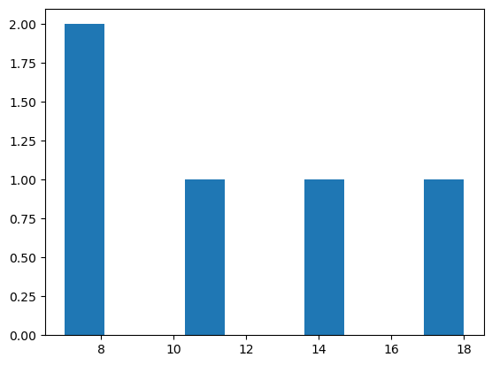

```python
hist(r2)
```

Use a trailing semi-colon to eliminate the text.

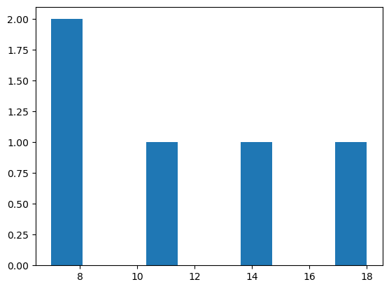

```python
hist(r2);
```

# Exercise 6

Generate and print a matrix (i.e. a $2$D array) of random *normals* of shape $2 \times 3$.

Hint: `np.random.randn(m, n)` samples from the standard normal distribution and generates an `m` by `n` matrix.

```python
x = np.random.randn(2, 3)
```

```python
x
```

```
array([[-1.55688234, -0.23381469, -1.27364592],
       [-1.99888757, -1.83017366,  0.87450442]])
```

# Exercise 7

Multiply the matrix you just created by $2$.

In linear algebra, this is called "scaling" the matrix.

```python
x * 2
```

[output not shown]

# Exercise 8

Now add the matrix to itself.

```python
x + x
```

[output not shown]

# Exercise 9

Now get a matrix of reciprocals.

Note: this is *not* the same as a reciprocal of a matrix.

```python
1 / x
```

[output not shown]

```python
# np.linalg.inv(x) # This is used to get the reciprocal, or inverse, of a matrix
```

# Exercise 10

Create two two-dimensional arrays.

Make one of $0$s and one of $1$s.

Give both a shape of $2 \times 4$.

```python
my_shape = (2, 4)
```

```python
z1 = np.zeros(my_shape)
```

```python
z1
```

```
array([[0., 0., 0., 0.],
       [0., 0., 0., 0.]])
```

```python
o1 = np.ones(my_shape)
```

```python
o1
```

```
array([[1., 1., 1., 1.],
       [1., 1., 1., 1.]])
```

# Exercise 11

Create an identity matrix with $4$ rows and columns.

```python
np.identity(4)
```

```
array([[1., 0., 0., 0.],
       [0., 1., 0., 0.],
       [0., 0., 1., 0.],
       [0., 0., 0., 1.]])
```

Note that identity matrices are square.

# Exercise 12

Generate a vector of random numbers of length $5$.

Then print a slice that consists of $3$ elements, beginning with the second element.

Then print a slice that excludes the first and last elements.

```python
x12 = np.random.randn(5)
```

```python
x12
```

```
array([-0.20266496,  0.19059664, -0.41064497, -0.3492225 ,  0.14831958])
```

```python
x12[1:4]
```

```
array([ 0.19059664, -0.41064497, -0.3492225 ])
```

```python
x12[1:-1]
```

```
array([ 0.19059664, -0.41064497, -0.3492225 ])
```

# Exercise 13

From the last array you created, select all elements $> 0.15$.

What is it called when you filter an array in this manner?

That is, using truth values in the indexer.

```python
x12[x12 > 0.15]
```

```
array([0.19059664])
```

This is called 'boolean indexing'.

Consider the boolean array:

```python
bool_idx = x12 > .15
```

```python
bool_idx
```

```
array([False,  True, False, False, False])
```

And this is our original array:

```python
x12
```

```
array([-0.20266496,  0.19059664, -0.41064497, -0.3492225 ,  0.14831958])
```

So, boolean indexing is something like:

```python
[a for a, b in zip(x12, bool_idx) if b]
```

```
[0.19059663613877315]
```

Or:

```python
[x for x in x12 * bool_idx if x]
```

```
[0.19059663613877315]
```

# Exercise 14

Generate a $2$D array of random numbers with a shape of $3 \times 3$.

Then, select the all the rows but the first, and all the columns but the last.

```python
x14 = np.random.randn(3,3)
```

```python
x14
```

```
array([[-0.71092828, -0.45263172, -1.60650309],
       [-0.15522386, -0.75890669,  1.55023292],
       [-1.18031566,  0.70695363,  0.08966593]])
```

```python
x14[1:, :-1]
```

```
array([[-0.15522386, -0.75890669],
       [-1.18031566,  0.70695363]])
```

```python
x14[1:, :2]
```

```
array([[-0.15522386, -0.75890669],
       [-1.18031566,  0.70695363]])
```

# Exercise 15

Write code to generate a new array based on the previous array and which sets all negative values to $0$.

The second array should be based on a copy of the first.

Then print both arrays.

```python
x15 = x14.copy()
x15[x15 < 0] = 0
```

```python
x14
```

```
array([[-0.71092828, -0.45263172, -1.60650309],
       [-0.15522386, -0.75890669,  1.55023292],
       [-1.18031566,  0.70695363,  0.08966593]])
```

```python
x15
```

```
array([[0.        , 0.        , 0.        ],
       [0.        , 0.        , 1.55023292],
       [0.        , 0.70695363, 0.08966593]])
```

# Exercise 16

Write a function called `roll_dice()` that uses `np.random.randint` and returns a sorted $1$D *list* of integers of length `n` for a die of `m` sides.

- Each integer is from $1$ to $m$ inclusive.
- Make the default value of `m` $6$.
- Give the user the option to return the results in reverse sort order. Set the default value to `False`.
- Return the results as a list.

Then

- Run it so that it rolls a $6$-sided die $10$ times. Print results with reverse sorting.
- Run it so that it rolls a $12$-sided die $10$ times. Print results with no sorting.

```python
def roll_dice(n, m=6, sort=False, reverse=False):
    '''
    This function returns a sorted list of integers of length n.
    Each integer is from 1 to 6 inclusive.
    '''
    x = np.random.randint(1, m+1, n)

    if sort:
        return sorted(x, reverse=reverse)
    else:
        return list(x)
```

```python
game1 = roll_dice(10, sort=True, reverse=True)
```

```python
game1
```

```
[6, 5, 5, 5, 4, 4, 3, 2, 1, 1]
```

```python
game2 = roll_dice(10, 12)
```

```python
game2
```

```
[1, 3, 2, 9, 4, 4, 7, 1, 6, 2]
```

# Exercise 17

Make a plot showing an example play where where $m = 50$, $n = 8$, and sorting is turned off.

```python
from matplotlib.pyplot import plot
```

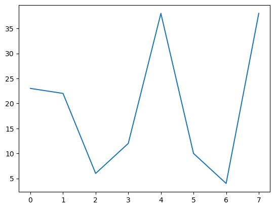

```python
plot(roll_dice(8, 50));
```

# Exercise 18

Write a NumPy program to compute the eigenvalues and eigenvectors of a given square array.

```python
m = np.mat("3 -2;1 0")
print(m)
```

```
[[ 3 -2]
 [ 1  0]]
```

```python
w, v = np.linalg.eig(m)
print( "Eigenvalues:",w)
print( "Eigenvectors:",v)
```

```
Eigenvalues: [2. 1.]
Eigenvectors: [[0.89442719 0.70710678]
 [0.4472136  0.70710678]]
```

# Exercise 19

Create two $2$D matrices $p$ and $q$ by hand, each of shape $2 \times 2$.

Then multiply them, i.e. get their dot product.

```python
p = [[1, 0], [0, 1]]
q = [[1, 2], [3, 4]]
```

```python
print('p:', p)
print('q:', q)
```

```
p: [[1, 0], [0, 1]]
q: [[1, 2], [3, 4]]
```

```python
result1 = np.dot(p, q)
print(result1)
```

```
[[1 2]
 [3 4]]
```

```python
result2 = np.dot(q, p)
print(result2)
```

```
[[1 2]
 [3 4]]
```

# Exercise 20

Use NumPy to calculate the difference between the maximum and the minimum values of a given array along the second axis.

**Expected Output:**

Original array:

```
[
    [0, 1, 2, 3, 4, 5],
    [6, 7, 8, 9, 10, 11]
]
```

Difference between the maximum and the minimum values of the said array:

```
[5, 5]
```

```python
x = np.arange(12).reshape((2, 6))
print(x.shape)
print(x)
```

```
(2, 6)
[[ 0  1  2  3  4  5]
 [ 6  7  8  9 10 11]]
```

Here are max and min along the first axis (cols)

```python
np.amax(x, axis=0), np.amin(x, axis=0)
```

```
(array([ 6,  7,  8,  9, 10, 11]), array([0, 1, 2, 3, 4, 5]))
```

Here are max and min along the second axis (rows)

```python
np.amax(x, axis=1), np.amin(x, axis=1)
```

```
(array([ 5, 11]), array([0, 6]))
```

Here is the difference:

```python
r1 = np.amax(x, axis=1) - np.amin(x, axis=1)
print(r1)
```

```
[5 5]
```

You may also use `np.ptp`.

> `numpy.ptp` is a function in the NumPy library that calculates the peak-to-peak range of values in an array. The peak-to-peak range is the difference between the maximum and minimum values. It can be computed along a specified axis or across the entire array.

```python
r2 = np.ptp(x, axis=1)
print(r2)
```

```
[5 5]
```

And here we show that the two methods produce the same result.

```python
np.allclose(r1, r2)
```

```
True
```

# Exercise 21

Use NumPy to sort a given array by the 2nd column.

Original array:

```
[
    [1, 5, 0],
    [3, 2, 5],
    [8, 7, 6]
]
```

Sorted array:

```
[
    [3, 2, 5],
    [1, 5, 0],
    [8, 7, 6]
]
```

```python
nums = np.random.randint(0,10,(3,3))
print(nums)
```

```
[[7 0 1]
 [6 9 0]
 [6 3 0]]
```

```python
print(nums[nums[:,1].argsort()])
```

```
[[7 0 1]
 [6 3 0]
 [6 9 0]]
```

# Exercise 22

Use NumPy to find the norm of a matrix or vector.

```python
v = np.arange(7)
vnorm = np.linalg.norm(v)
print(v)
print("Vector norm:", vnorm)
```

```
[0 1 2 3 4 5 6]
Vector norm: 9.539392014169456
```

```python
m = np.matrix('1, 2; 3, 4')
mnorm = np.linalg.norm(m)
print(m)
print("Matrix norm:", mnorm)
```

```
[[1 2]
 [3 4]]
Matrix norm: 5.477225575051661
```

# Exercise 23

Use NumPy to calculate the QR decomposition of a given matrix.

```python
m = np.array([[1,2],[3,4]])
print(m)
```

```
[[1 2]
 [3 4]]
```

```python
result =  np.linalg.qr(m)
print(result)
```

```
(array([[-0.31622777, -0.9486833 ],
       [-0.9486833 ,  0.31622777]]), array([[-3.16227766, -4.42718872],
       [ 0.        , -0.63245553]]))
```